# Milestone Report: Coursera Data Science Capstone Project

Piyush Verma

March 17, 2018

## Executive Summary

This is one step towards building a basic text predictive model. The dataset used here has been downloaded from [here](https://d396qusza40orc.cloudfront.net/dsscapstone/dataset/Coursera-SwiftKey.zip). The dataset is provided by a company called swiftkey in partnership with Coursera. The dataset was made by taking words from users’ tweets, blogs and words from the news articles. The provided dataset is structured but requires basic cleaning which is discussed in later section. Following are the files:

- en_US.blogs.txt : words scraped from blogs
- en_US.news.txt : words scraped from news articles
- en_US.twitter.txt : words scraped from twitter

```r
## Necessary libraries
suppressWarnings(library(tm))
suppressWarnings(library(knitr))
suppressWarnings(library(stringi))
suppressWarnings(library(RWeka))
suppressWarnings(library(ggplot2))
```

## Data Reading

Code below reads the twitter, news and blogs file line by line, and counts the: a) total number of lines, b) total number of words and the maximum words in a line for that text file.

```r
## Reading files
t_line<-c()
t_words<-c()
max_words<-c()

files<-list.files(pattern = "en_US.")
    for(i in 1:3){
        con<-file(files[i],open = "r")
        text<-suppressWarnings(readLines(con))
        t_line[i]<-length(text) # Counting total number of lines
        t_words[i]<-sum(stri_count_words(text)) # Counting total number of words
        max_words[i]<-max(stri_count_words(text)) # Counting max number of words in 1 line
      close(con)
    }
tab<-data.frame(Files = files[1:3], Total_Lines = t_line, Total_Words = t_words, Max_Word = max_words)
kable(tab[order(tab$Total_Lines,decreasing = TRUE),]) # Output high level info for all the files
```

|  | Files | Total_Lines | Total_Words | Max_Word |
| --- | --- | --- | --- | --- |
| 3 | en_US.twitter.txt | 2360148 | 30218125 | 60 |
| 1 | en_US.blogs.txt | 899288 | 38154238 | 6726 |
| 2 | en_US.news.txt | 77259 | 2693898 | 1123 |

## Data Understanding

Code below, generates training and testing dataset. Since the complete combined text would be enourmous (71 million), we would take 0.5% of it to build a training dataset which would be roughly 350,000 words. We hope these many words should cover majority of commonly used words which a potential user can use in the app and look for a prediction.

```r
## Cleaning text files
final_text_combined<-NULL
    for(i in 1:3){
      final_text_combined<-append(final_text_combined,suppressWarnings(readLines(file(files[i],open="r"))))
    }
all<-length(final_text_combined)
index<-sample(1:all,0.005*all)
combined_sample<-final_text_combined[index]
```

## Data Cleaning

We expect latin words, special characters like chinese symbols, punctuations, numbers and profanity words to flow into our sample dataset. And we don’t want to use them to build our model. So in steps below we will be removing them using the “tm” package.

```r
## This step removes 16% of bad characters like
dat2 <- unlist(strsplit(combined_sample, split=", ")) # convert string to vector of words
dat3 <- grep("dat2", iconv(dat2, "latin1", "ASCII", sub="dat2")) # Find indices of words with non-ASCII characters
dat4 <- dat2[-dat3] # Subset original vector of words to exclude words with non-ASCII char
combined_sample <- paste(dat4, collapse = ", ") # Convert vector back to a string,


profanityWords<-read.table("./profanity_filter.txt", header = FALSE)
removeURL<-function(x) gsub("http[[:alnum:]]*", "", x)
#mystopwords <- c("[I]","[Aa]nd", "[Ff]or","[Ii]n","[Ii]s","[Ii]t","[Nn]ot","[Oo]n","[Tt]he","[Tt]o")

## Corpora Preparation
EN_corpora<-VCorpus(VectorSource(combined_sample), readerControl = list(language="en"))

EN_corpora<-tm_map(EN_corpora, removeWords, stopwords('english'))
#EN_corpora<-tm_map(EN_corpora, removeWords, stopwords('SMART'))
#EN_corpora<-tm_map(EN_corpora, removeWords, stopwords('german'))
#EN_corpora<-tm_map(EN_corpora, removeWords, mystopwords)
EN_corpora<-tm_map(EN_corpora, content_transformer(function(x) iconv(x, to="UTF-8", sub="byte")))
EN_corpora<-tm_map(EN_corpora, content_transformer(tolower))
EN_corpora<-tm_map(EN_corpora, content_transformer(removePunctuation), preserve_intra_word_dashes=TRUE)
EN_corpora<-tm_map(EN_corpora, removeWords, profanityWords$V1) #Profanity Filter
EN_corpora<-tm_map(EN_corpora, content_transformer(removeNumbers))
EN_corpora<-tm_map(EN_corpora, content_transformer(removeURL))
#EN_corpora<-tm_map(EN_corpora, stemDocument, language='english')
EN_corpora<-tm_map(EN_corpora, stripWhitespace)
EN_corpora<-tm_map(EN_corpora, PlainTextDocument)
```

## Data Exploration

Below are the codes and the charts generating them.

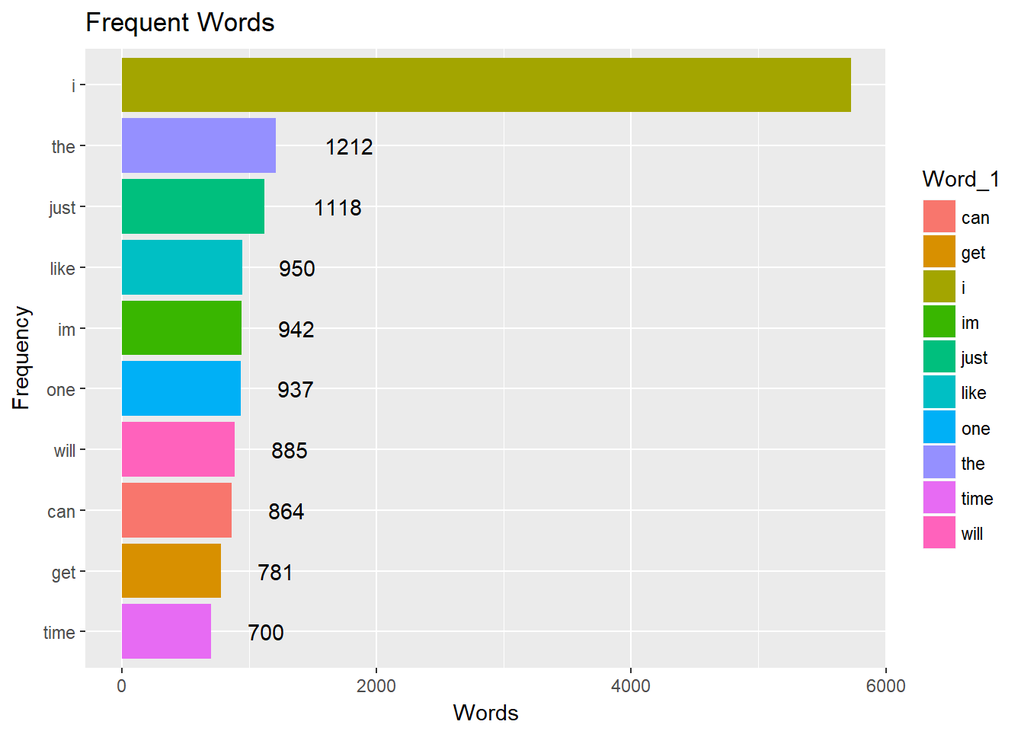

```r
## Unigram Frequnecy Barplot
unigram<-NGramTokenizer(EN_corpora, Weka_control(min = 1, max = 1,delimiters = " \\r\\n\\t.,;:\"()?!"))
unigram<-data.frame(table(unigram))
unigram<-unigram[order(unigram$Freq,decreasing = TRUE),]
names(unigram)<-c("Word_1", "Freq")
unigram$Word_1<-as.character(unigram$Word_1)
p<-ggplot(data=unigram[1:10,], aes(x = reorder(Word_1,Freq), y = Freq, fill = Word_1))
p<-p + geom_bar(stat="identity") + coord_flip() + ggtitle("Frequent Words")
p<-p + geom_text(data = unigram[1:10,], aes(x = Word_1, y = Freq, label = Freq), hjust=-1, position = "identity")
p<-p + labs(x="Frequency",y="Words")
p
```

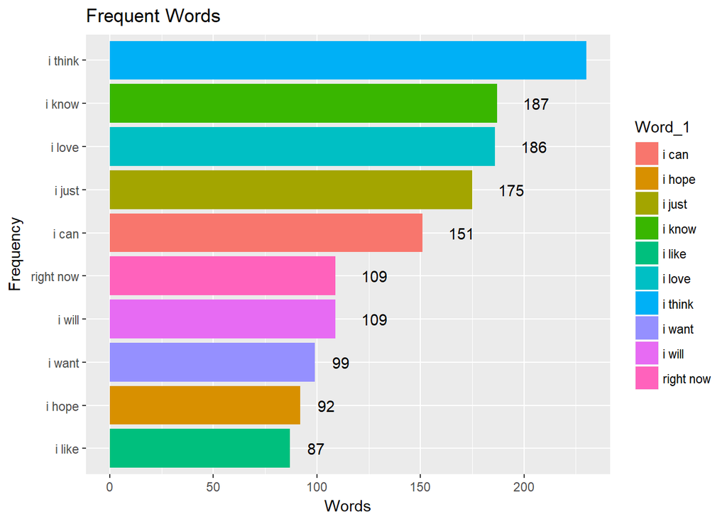

```r
## Bigram Frequnecy Barplot
bigram<-NGramTokenizer(EN_corpora, Weka_control(min = 2, max = 2,delimiters = " \\r\\n\\t.,;:\"()?!"))
bigram<-data.frame(table(bigram))
bigram<-bigram[order(bigram$Freq,decreasing = TRUE),]
names(bigram)<-c("Word_1", "Freq")
bigram$Word_1<-as.character(bigram$Word_1)
q<-ggplot(data=bigram[1:10,], aes(x = reorder(Word_1,Freq), y = Freq, fill = Word_1))
q<-q + geom_bar(stat="identity") + coord_flip() + ggtitle("Frequent Words")
q<-q + geom_text(data = bigram[1:10,], aes(x = Word_1, y = Freq, label = Freq), hjust=-1, position = "identity")
q<-q + labs(x="Frequency",y="Words")
q
```

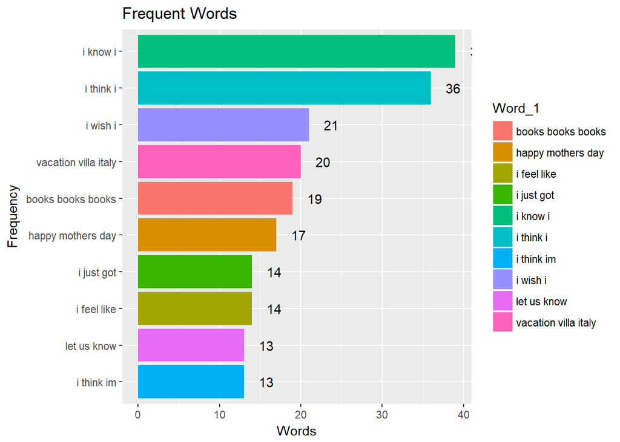

```r
## Trigram Frequnecy Barplot
trigram<-NGramTokenizer(EN_corpora, Weka_control(min = 3, max = 3,delimiters = " \\r\\n\\t.,;:\"()?!"))
trigram<-data.frame(table(trigram))
trigram<-trigram[order(trigram$Freq,decreasing = TRUE),]
names(trigram)<-c("Word_1", "Freq")
trigram$Word_1<-as.character(trigram$Word_1)
r<-ggplot(data=trigram[1:10,], aes(x = reorder(Word_1,Freq), y = Freq, fill = Word_1))
r<-r + geom_bar(stat="identity") + coord_flip() + ggtitle("Frequent Words")
r<-r + geom_text(data = trigram[1:10,], aes(x = Word_1, y = Freq, label = Freq), hjust=-1, position = "identity")
r<-r + labs(x="Frequency",y="Words")
r
```

## Futher discussions on the scope

- If a user enters a misspelled word, say “goot” instead of “good”, algorithm can be improved to correct the prediction with the most similar word and then predict the next word based on that
- Since we have to compromise the training set for app performance, one scope is to big data techniques to overcome that and make a more accurate model
- Next step is to build a R shiny app
- The app would take a string of words from user and predict the next word which the user would have typed next, based on backoff model